# Line Intercept Riparian Survey 3 Riparian Cover

Oliver Franklin

2025-12-04

# Data import

For this script we import the tidied dataframe generated by the Data Wrangling script, which was exported to your output folder.

Here we will examine how densely vegetated the surveyed area is. We will explore the following:

- Cover density across the surveyed riparian area;
- Cover density across the riparian area, subset by height class (canopy/mid/low); and
- Cover density of individual species within the riparian area.

## Plant Species and ‘Non-plant’ Occurrences

Remember that our data includes both plant and ‘non-plant’ occurrences observed in the field. Consider where non-plant data needs to be excluded prior to summing or taking means of the data: For relative plant abundance, we recommended removing the non-plant occurrences. When exploring cover density, we typically remove the non-plant occurrences (e.g., to avoid including extents of riprap etc. in the total cover per m figure).

However, there are cases where it may be of interest to explore the cover density of particular non-plant features. You may be interested in the extent of saturated soils in the riparian area. Or, perhaps for your study you want to exclude exposed bedrock to understand how vegetation changes in gravel deposits. The code chunk below can be modified to include non-plant occurrences, but by default we will exclude them and focus on density metrics based only on the plant species occurrences.

```r
include_non_plants <- FALSE   # change to TRUE to keep the non-plant occurrences (Plant_codes starting with "!")
```

## Overhanging Vegetation

Another consideration is whether or not to include overhanging vegetation in the cover metrics. Although vegetation that extends horizontally above the water surface is technically outside of the transect, we recommended that it was measured because of its functional importance to aquatic life. Consider whether you would want two otherwise identical transects to return different cover metrics if only one transect featured overhanging vegetation. By default, our code excludes overhanging vegetation from cover metrics, but extents of overhanging vegetation can be included using the code below (note that excluding overhanging vegetation does not exclude an entire plant, only the extent that is above the water surface / beyond the transect 0 m mark).

```r
include_overhanging <- FALSE   # change to TRUE to keep overhanging extents of vegetation (negative Start_location values)
```

## Riparian Vegetation Cover Density

The density of vegetation cover is of interest because it provides information on the amount of vegetation present, rather than the proportions of a given species relative to other types of vegetation (relative abundance). Cover may be of particular importance in restoration because one would expect the amount of vegetation present to be associated with the riparian area’s resilience against invasive plants, the contribution of leaf litter and insect drop to aquatic ecosystems, the filtering of pollutants, shading, etc.

It is likely that your restoration objectives involve both achieving a certain level of plant density as well as a certain level of diversity derived from relative abundance data. So once you have understood the metrics and tests we generate in this script, you should consider any patterns that stand out alongside any changes in relative abundance from the preceding script. These types of interpretations are rarely simple, so we recommend getting together with your restoration partners to discuss.

Considering both cover density and plant community composition together helps to overcome a limitation of our data collection method. In short, you must be cautious when interpreting changes in cover that are also associated with significant shifts in the plant community composition. In order to avoid overly time consuming field surveys, we grouped together as a single occurrence any observations of stands of the same plant species that were contiguous and in the same height class (e.g., a monoculture of sedges might be many individual plants but would be recorded as one occurrence of sedge spanning *x* metres). But if later you observed many other plants intermixed with the sedge, then we would expect to have recorded more overlaps of individual plants (e.g., each skunk cabbage established within a sedge stand overlaps to some degree). This additional overlap will increase the cover metrics. Whether or not this is of concern for your interpretation may depend on your focal cover objective.

### Total Cover Density (combined height classes)

In our data wrangling script we have already defined the length of your riparian transects, and we will use the extents of each plant species as a proportion of the transect length to generate cover metrics. First we will calculate the total cover density per transect, which incorporates all vegetation at any height class and probably best reflects what you think of as vegetation density. Note that the total cover (m vegetation per m riparian transect) is expected to be >1.0, due to the presence of overlapping multi-canopy vegetation (and overhanging vegetation, if included).

We will display the mean and sd values for each site and year below, and will export this table and the table with the values per transect to your output folder.

| Site | year | BankGroup | Summary |
| --- | --- | --- | --- |
| CONTROL | 2024 | All | 2.392 (0.971) |
| CONTROL | 2026 | All | 4.732 (2.608) |
| Turkey Brook | 2024 | All | 2.941 (0.459) |
| Turkey Brook | 2026 | All | 1.758 (0.699) |

It may also be interest to examine the density of vegetative cover at different height classes. Note that these different height classes are not independent - canopy density may increase as plant species composition and size changes, and higher densities in the canopy and midlayer influence the density and species composition below.

We will generate a figure per site-year showing density by height class and transect, which will be displayed below and exported to your output folder.

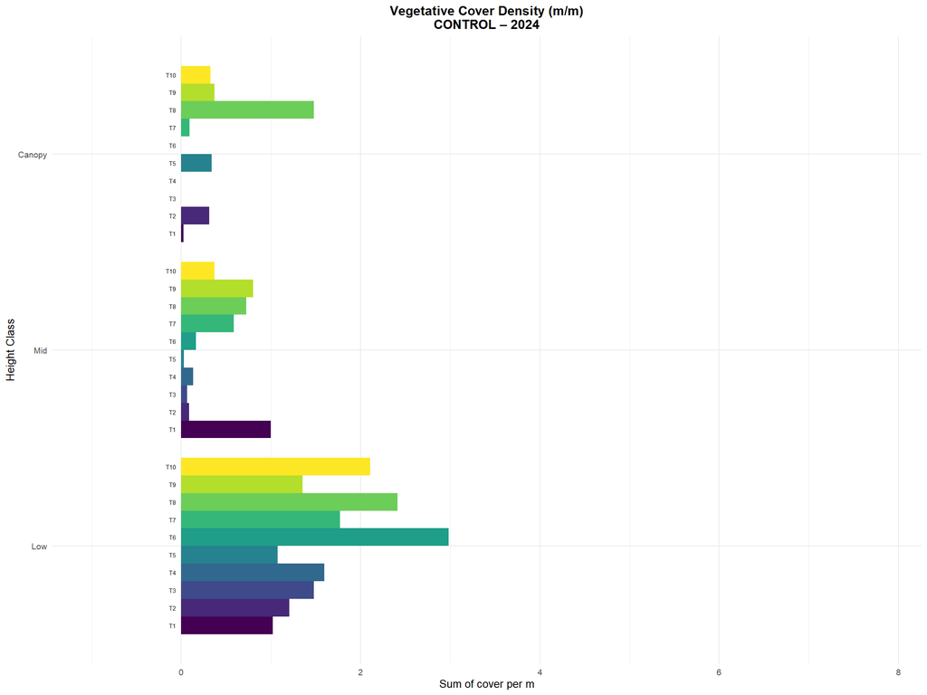

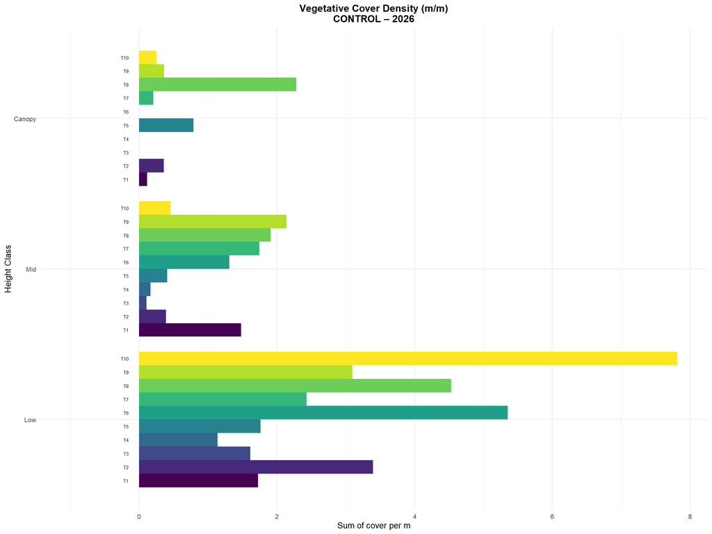

```
##
## $`Turkey Brook_2024`
```

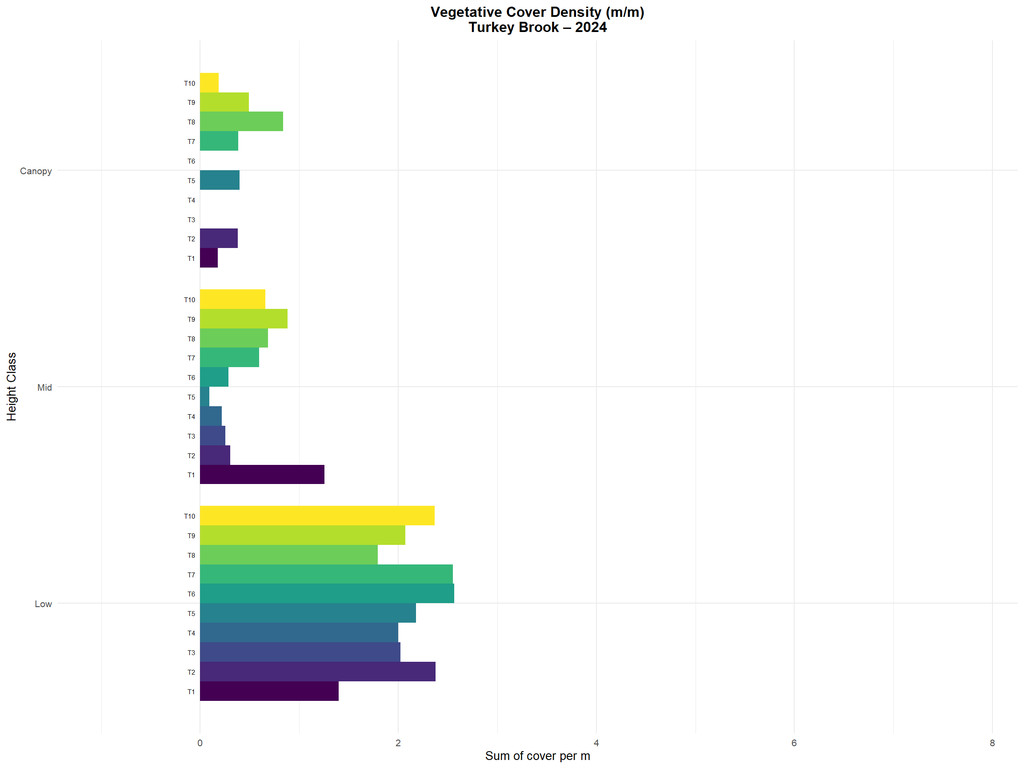

```
##
## $`Turkey Brook_2026`
```

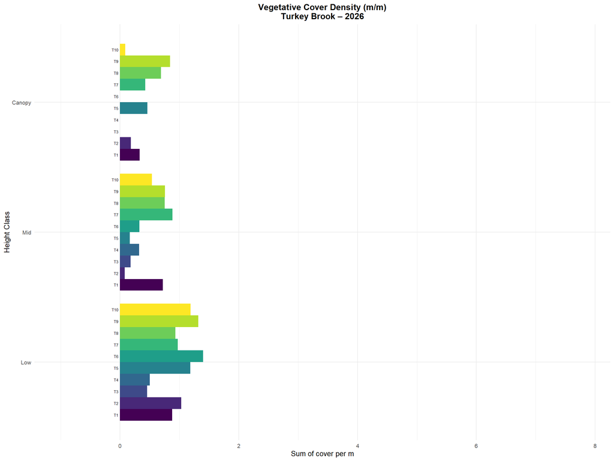

And next, we will display the associated means and sd values for the height class plant density. The values per transect are exported to your output folder.

| Site | year | Transect_ID | Low | Mid | Canopy |
| --- | --- | --- | --- | --- | --- |
| CONTROL | 2024 | Mean and SD | 1.7 (0.632) | 0.397 (0.355) | 0.295 (0.445) |
| CONTROL | 2026 | Mean and SD | 3.285 (2.09) | 1.011 (0.784) | 0.436 (0.692) |
| Turkey Brook | 2024 | Mean and SD | 2.133 (0.36) | 0.523 (0.361) | 0.285 (0.267) |
| Turkey Brook | 2026 | Mean and SD | 0.985 (0.315) | 0.471 (0.293) | 0.302 (0.301) |

## Individual Species or Feature Cover Densities

We can also explore the cover density of individual species, or of the non-plant occurrences that you recorded. It may be of interest to (e.g.) compare the average extents of saturated soils, the amount of scoured bare substrates, or the density of a particular species such as an indicator species, a culturally important plant, or an invasive species of concern.

We will default to including the non-plant values while still excluding the overhanging vegetation, but this can be changed if you alter the code below, as before:

```r
include_non_plants <- TRUE   # change to FALSE to remove the non-plant occurrences (Plant_codes starting with "!")
include_overhanging <- FALSE   # change to TRUE to keep overhanging extents of vegetation (negative Start_location values)
```

The mean and sd density values for species/features by height cover across transects in the reach are displayed below. We have exported to your output folder this table as well as a table with the density values per species per transect.

| Site | year | Bank_group | plant_code | L_mean | L_sd | M_mean | M_sd | C_mean | C_sd | Other_mean | Other_sd |
| --- | --- | --- | --- | --- | --- | --- | --- | --- | --- | --- | --- |
| CONTROL | 2024 | Combined | !WET | 0 | 0 | 0 | 0 | 0 | 0 | 0.005097961933333331 | 0.01612117113416879 |
| CONTROL | 2024 | Combined | ALNUS | 0 | 0 | 2.975056666666666e-06 | 9.407955234735004e-06 | 0.12158976642 | 0.1509135782104377 | 0 | 0 |
| CONTROL | 2024 | Combined | CORNSER | 0 | 0 | 0.0006515902566666666 | 0.00206050931224038 | 0 | 0 | 0 | 0 |
| CONTROL | 2024 | Combined | IMPAGLA | 0.07888983652 | 0.1497814085879703 | 0 | 0 | 0 | 0 | 0 | 0 |
| CONTROL | 2024 | Combined | LONIINV | 0 | 0 | 0.06148968397333333 | 0.1454163911627782 | 0 | 0 | 0 | 0 |
| CONTROL | 2024 | Combined | LYSIAME | 0.48177018865 | 0.537793949142996 | 0 | 0 | 0 | 0 | 0 | 0 |
| CONTROL | 2024 | Combined | MALUFUS | 0 | 0 | 0.02293499653666667 | 0.068745365523644 | 0.009485182839999998 | 0.02999478179754446 | 0 | 0 |
| CONTROL | 2024 | Combined | PHALARU | 0.93447021601 | 0.3778390910358175 | 0.1408863207833334 | 0.3151384166017379 | 0.06942864250333333 | 0.2195526451641078 | 0 | 0 |
| CONTROL | 2024 | Combined | POPUTRI | 0 | 0 | 0.01100958606 | 0.02194887960533601 | 0.04873016398666667 | 0.1540983089513777 | 0 | 0 |
| CONTROL | 2024 | Combined | ROSANUT | 0.0294261505 | 0.09305365835090257 | 0 | 0 | 0 | 0 | 0 | 0 |

[output cut: 66 more lines]

## Inferential Tests

If you have a control or reference site and multiple years of data, we can apply inferential statistical tests to see if the observed changes are likely to be due to chance variability, or are consistent with the expected effects of your restoration actions. We will test whether there are statistically significant changes in the overall plant cover density values, using data from each transect grouped by Site and year, and we will also provide a method to test for significant changes in cover density for a given plant species (or ‘non-plant’ feature).

You will be familiar with p values of 0.05 (observed result expected just due to chance 1 in 20 times) and we will use p=0.05 as our cut-off here. However, depending on your adaptive management plans, you may be willing to accept different levels of certainty, and p values of 0.1 are not unheard of in restoration projects. This all depends on the risk tolerance of you and your team, and should be established before conducting analyses.

It is not appropriate to use ANOVA for this data because the cover density values are bounded by 0, are likely skewed, and because the data contain many zeroes (when a plant is present in certain transects, but not others, those other transects are assigned a zero value for that plant). Below we will use generalised linear models (GLMs), which are similar to linear regression but involve a link function and a non-normally distributed response variable.

*NB* We provide these tests as a general framework, and caution against using them if you do not understand what the models are doing. We may not have an opportunity to refine them (changes in government priorities) but consider them a useful placeholder for now. We will apply GLMs with a Gamma distribution (adjusting zeroes to 0.001) and a log link, because our response variable (cover density) should be positive, potentially zero-inflated, often skewed, and without a known upper bound (overlapping cover and height classes means densities exceeding 1m/m). However, actual data collected across a variety of ecosystems and stages of recovery might be very different, so we caution against taking the results of these GLMs at face value. If in doubt, our best advice is to rely on your own (and your restoration partners’) interpretation of the raw data and the figures we have already presented above.

The tests are carried out below, after we specify the before and after data that you wish to compare.

#### Before / After Years

Enter your before and after years in the below code, you may have more than one year in each category. Remember that these should balance (equal number of years before as after), but they need not be consecutive years. If you do not have balanced data (e.g., only one year was possible before project implementation) be very cautious in running and interpreting the tests. You could select only a subset of your data to keep the comparison balanced, but if you do this for more than one set of dates you must account for the multiple comparisons inflating the likelihood of a Type I error (false positive).

```r
# Define "Before" and "After" years
before_years <- c(2024) #add more years inside brackets if needed, e.g. 'c(2024, 2025, 2026)'
after_years <- c(2026) #add more years inside brackets if needed, e.g. 'c(2027, 2029, 2036)'
```

### Cover density: Generalised Linear Model (GLM)

The GLM will assess the statistical significance of observed changes in cover density, which is assessed at the level of each individual transect. The GLMs will be run for each height class separately, and for left and right banks separately if this has previously been specified. The interaction of Site*Time is interpretable as a change at your restoration site being distinct from a change at your control site. It is important to refer to your *a priori* hypotheses and predictions before interpreting these results, as we will generate a number of tests and you must avoid interpreting them selectively (there might be significant results that appear by chance due to the number of tests being run).

Because of the potential number of model outputs and diagnostic figures generated, we will suppress them from being displayed. Instead, we generate a summary table that only displays the Site*Time interaction model results, and we will export the full model results to your output folder. We do this because many people using this code will not want to interpret these models. If you do wish to interpret them, you should review the full models and the diagnostics (instructions within code).

[output not shown]

### Species or Feature Cover Density: Generalised Linear Model (GLM)

Now we will apply the same inferential test to individual species (or non-plant features) that you encountered.

In the next chunk of code you can specify a particular species/feature and a height class (or combine all height classes). A glm will then be run for that species (and height class) so that you can assess the statistical significance of the observed changes in cover density of that species at the restoration site compared with the control or reference site (i.e., the Site*Time interaction). The height class option is, as before, to allow you to assess species as a standard biological concept, or explore the different functions that we have assumed that different heights of plant can play. Note that if you are specifying a non-plant feature, you should set the target_height to “other”.

If this seems a bit speculative to you, it probably is. As always, you should only run these tests if you have *a priori* hypotheses and predictions for the particular species/feature, and should avoid the temptation to dredge through various species looking for any significant changes (which you would surely observe, just due to chance, if you look at a number of species).

```r
target_species <- "PHALARU"   # <-- add plant_code value for focal species
target_height <- "L"           # <-- define "C", "M", "L", or "combo" = all height classes, "other" = non-plants
```

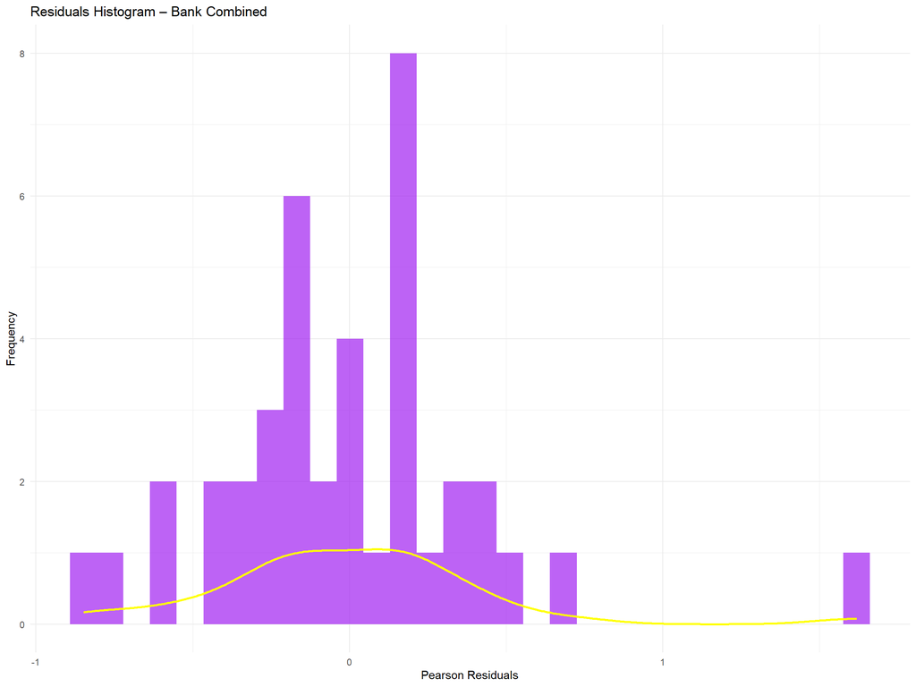

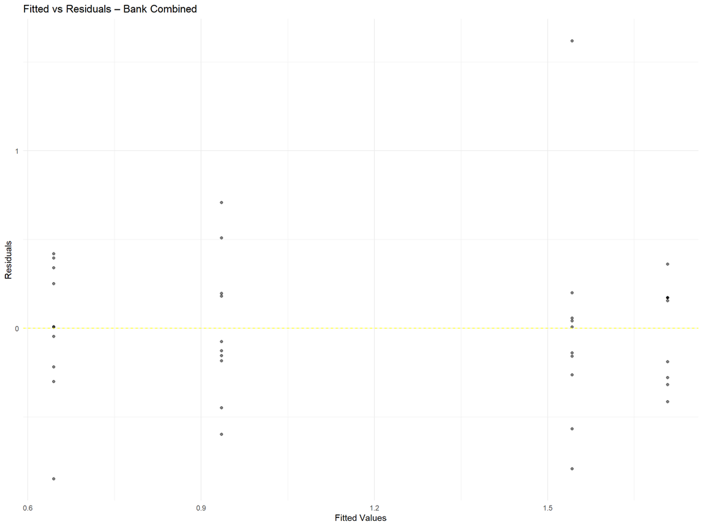

```
## $Combined
##
## Call:
## glm(formula = cover.per.m_adj ~ Site * Time_Category, family = Gamma(link = "log"),
##     data = species_bank)
##
## Coefficients:
##                                      Estimate Std. Error t value Pr(>|t|)
## (Intercept)                            0.4335     0.1416   3.061 0.004160 **
## SiteTurkey Brook                      -0.8718     0.2003  -4.352 0.000107 ***
## Time_CategoryBefore                   -0.5002     0.2003  -2.497 0.017233 *
## SiteTurkey Brook:Time_CategoryBefore   1.4738     0.2833   5.202 8.09e-06 ***
## ---
## Signif. codes:  0 '***' 0.001 '**' 0.01 '*' 0.05 '.' 0.1 ' ' 1
##
## (Dispersion parameter for Gamma family taken to be 0.2006425)
##
##     Null deviance: 14.4257  on 39  degrees of freedom
## Residual deviance:  8.5975  on 36  degrees of freedom
## AIC: 64.129
##
## Number of Fisher Scoring iterations: 5
```

```
## $Combined
## $Combined$data
## # A tibble: 40 × 14
##    Site     year plant_code Height_class Transect_ID cover.per.m Bank  has_bank
##    <chr>   <int> <chr>      <chr>              <int>       <dbl> <chr> <lgl>
##  1 CONTROL  2024 PHALARU    L                      1       0.374 <NA>  FALSE
##  2 CONTROL  2024 PHALARU    L                      2       0.815 <NA>  FALSE
##  3 CONTROL  2024 PHALARU    L                      3       1.41  <NA>  FALSE
##  4 CONTROL  2024 PHALARU    L                      4       1.60  <NA>  FALSE
##  5 CONTROL  2024 PHALARU    L                      5       0.761 <NA>  FALSE
##  6 CONTROL  2024 PHALARU    L                      6       1.10  <NA>  FALSE
##  7 CONTROL  2024 PHALARU    L                      7       0.864 <NA>  FALSE
##  8 CONTROL  2024 PHALARU    L                      8       0.790 <NA>  FALSE
##  9 CONTROL  2024 PHALARU    L                      9       0.515 <NA>  FALSE
## 10 CONTROL  2024 PHALARU    L                     10       1.12  <NA>  FALSE
## # ℹ 30 more rows
## # ℹ 6 more variables: Bank_group <chr>, Height_class_clean <fct>,
## #   Time_Category <chr>, cover.per.m_adj <dbl>, residuals <dbl>, fitted <dbl>
##
## $Combined$residual_plot
```

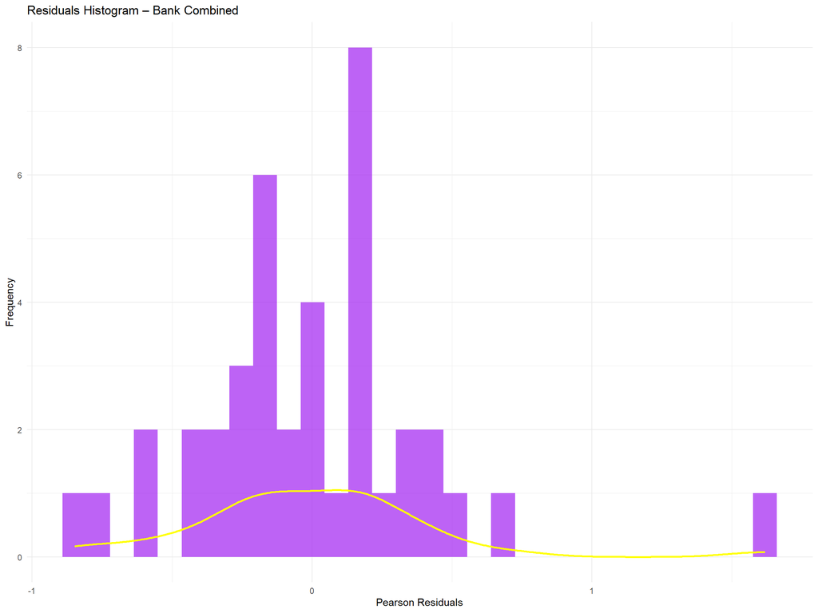

```
##
## $Combined$fitted_vs_resid_plot
```

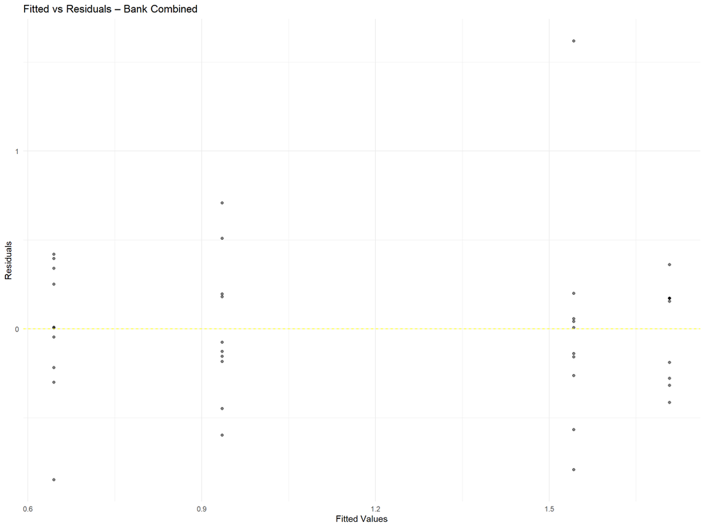

So that is it for cover density for now. As mentioned previously, we hope to return to this code to refine it. Until then, we hope it is useful. For any future refinements we will ensure we keep using the same metrics calculated in the same way (so that it is comparable to anything generated now) but we hope to add to the metrics and provide more options, as well as improving the inferential testing we offer.

Next we will move onto some characteristics of the vegetation: wetland (hydrophyte) status, invasive status, and overhanging extents of the vegetation.